# Session 1 - Intro to R and RStudio etc.

ISM2324

07./08.11.2023

# Intro to R and RStudio

We will have a look at its structure and functionality during the course of this session. For further info, you may want to read the [Introduction to RStudio](https://www.datacamp.com/tutorial/r-studio-tutorial) on Datacamp.

## Set working directory

*Postscript:* To avoid the problems some of you encountered in setting the working directory on a Mac, you may also use the menu and click Session -> Set working directory -> Choose directory…

## Load packages

```r
library(tidyverse)
```

- You need to load the required packages anew in each R session
- No quotation marks, only one package per call
- In future sessions, we will also use the `pacman` package which is more convenient for package management
- Type `search()` to get a list of all loaded packages

## An alternative - the `pacman`-package

- there’s also an option that combines the `install.packages` and `library` functions -> the `pacman`-package (short for package management)
- usually you just require the p_load() function from the package, but what’s so special about it?
- p_load() does two things at once: First, it checks if the required package is already installed. If not, it will handle the installation for you. Second, when all the required packages are installed, it will load the packages using `library`.
- another positive aspect: you may just add as many packages as you want just using a “,” (e.g. pacman::p_load(tidyverse, readxl, lubridate, survey))
- just the function `p_load` unfortunately isn’t enough, you have to specify the package as well. That’s possible using “:”.

```r
pacman::p_load(tidyverse) # this will work
```

## Get help

To get help on a package (or function or any other built-in R object), write `help(packagename)` or just `??packagename`. You can also click the **Help** tab in the bottom-right pane!

## Load / import data

Use the `data()` function to load data that is included in any R package that you loaded. Use the `load()`function to load .Rda data files that have been saved using the `save()` function. To import data from other formats such as .csv, use the `read_csv`function from the `readr`package (included in `tidyverse`). In RStudio, you can also click File -> Import Dataset -> From text(readr)

## Your task:

- Install and load the `survey`package
- Load the `election` data contained in that package
- Use functions `dim()`, `head()`, `names()`, `summary()`, and `View()` to inspect the data. What does the data frame contain?
- Use functions from the `dplyr`package to compute vote proportions for the three candidates
- Use the generic `hist()` function and the `ggplot()` function to plot the distribution of the vote proportions for G.W. Bush

## Sample solution

```r
#install.packages("survey")
library(survey)
```

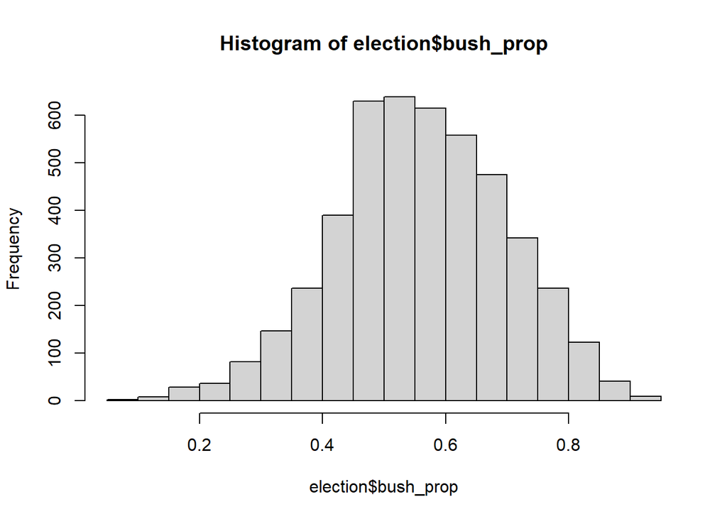

```r
data(election)

election <- election %>%
  mutate(bush_prop = Bush / votes,
         kerry_prop = Kerry / votes,
         nader_prop = Nader / votes)

hist(election$bush_prop)
```

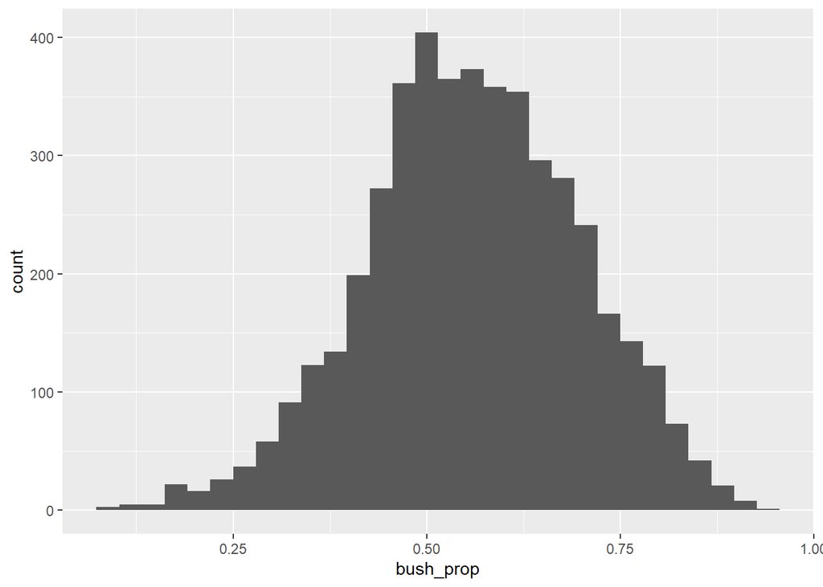

```r
ggplot(election, aes(x = bush_prop)) +
  geom_histogram()
```

- You need to uncomment the `install.packages()` command (I have already installed the survey package)